# 그래프 시각화 환경 작동

# 라이브러리 설치

- 라이브러리를 설치하고선 Kernel을 재시작해 주세요!
- 제일 위 메뉴 중 `Kernel` - `Restart Kernel...`을 클릭하시면 됩니다.

# 라이브러리 불러오기

# 함수들

#### 회사명으로 주식 종목 코드를 획득할 수 있도록 하는 함수

#### 종목코드 목록 다운로드

# 코드 실행

### 삼성전자

삼성전자의 종목코드를 구해서, start 날짜부터 end 날짜까지의 주가 정보를 가져오겠습니다.

```
INFO:numexpr.utils:Note: NumExpr detected 44 cores but "NUMEXPR_MAX_THREADS" not set, so enforcing safe limit of 8.
INFO:numexpr.utils:NumExpr defaulting to 8 threads.
```

Yahoo API를 사용하여 데이터를 가져옵니다. 주가 정보는 High, Low, Open, Close, Volume, Adj_Ratio로 구성되어 있습니다.

| Date | High | Low | Open | Close | Volume | Adj_Ratio |
| --- | --- | --- | --- | --- | --- | --- |
| 2020-05-20 | 50200.0 | 49800.0 | 50000.0 | 50000.0 | 14896899 | 1.0 |
| 2020-05-21 | 50400.0 | 49850.0 | 50300.0 | 49950.0 | 14949266 | 1.0 |
| 2020-05-22 | 49800.0 | 48600.0 | 49600.0 | 48750.0 | 19706284 | 1.0 |
| 2020-05-25 | 48900.0 | 48450.0 | 48750.0 | 48850.0 | 14337913 | 1.0 |
| 2020-05-26 | 49450.0 | 48600.0 | 48700.0 | 49250.0 | 15127490 | 1.0 |
| 2020-05-27 | 50000.0 | 48800.0 | 48950.0 | 49900.0 | 19548479 | 1.0 |
| 2020-05-28 | 51200.0 | 49900.0 | 51100.0 | 50400.0 | 31309318 | 1.0 |
| 2020-05-29 | 50700.0 | 49700.0 | 50000.0 | 50700.0 | 27596961 | 1.0 |
| 2020-06-01 | 51200.0 | 50600.0 | 50800.0 | 51200.0 | 16949183 | 1.0 |
| 2020-06-02 | 51500.0 | 50800.0 | 51000.0 | 51400.0 | 14247933 | 1.0 |
| 2020-06-03 | 55000.0 | 51700.0 | 51800.0 | 54500.0 | 49257814 | 1.0 |
| 2020-06-04 | 57000.0 | 54600.0 | 55800.0 | 54600.0 | 40220334 | 1.0 |
| 2020-06-05 | 55900.0 | 54000.0 | 54400.0 | 55500.0 | 22743629 | 1.0 |
| 2020-06-08 | 56500.0 | 54700.0 | 56400.0 | 54900.0 | 25634965 | 1.0 |
| 2020-06-09 | 56500.0 | 54400.0 | 55800.0 | 55500.0 | 23998831 | 1.0 |
| 2020-06-10 | 55900.0 | 54900.0 | 55100.0 | 55400.0 | 16742493 | 1.0 |
| 2020-06-11 | 55100.0 | 53200.0 | 54500.0 | 54300.0 | 33815123 | 1.0 |
| 2020-06-12 | 52800.0 | 51500.0 | 52100.0 | 52300.0 | 26976019 | 1.0 |
| 2020-06-15 | 52000.0 | 49900.0 | 51400.0 | 49900.0 | 28772921 | 1.0 |
| 2020-06-16 | 52100.0 | 50600.0 | 51200.0 | 52100.0 | 21808375 | 1.0 |
| 2020-06-17 | 52900.0 | 51300.0 | 52100.0 | 52200.0 | 26672595 | 1.0 |
| 2020-06-18 | 52300.0 | 51600.0 | 52200.0 | 52300.0 | 15982926 | 1.0 |
| 2020-06-19 | 52900.0 | 51600.0 | 52600.0 | 52900.0 | 17429411 | 1.0 |

Prophet에서 예측할 때 사용하는 데이터의 이름은 `ds`와 `y` 입니다.  
이것에 맞게 `Date`는 `ds`로, `Close`는 `y`로 바꾸어 줍니다.

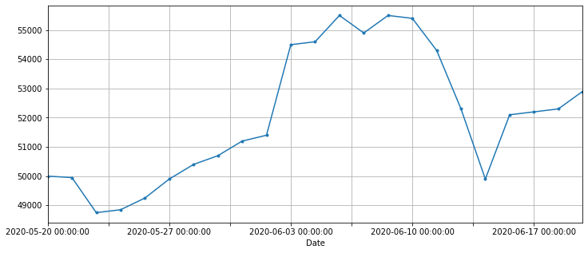

주어진 데이터에서 3일 뒤의 자료까지 예측한다고 해봅시다.  
즉, 2020-06-19 이후로 2020-06-22 까지 3일 간의 자료를 예측해 봅니다.

```
INFO:fbprophet:Disabling yearly seasonality. Run prophet with yearly_seasonality=True to override this.
INFO:fbprophet:Disabling daily seasonality. Run prophet with daily_seasonality=True to override this.
INFO:fbprophet:n_changepoints greater than number of observations.Using 17.
```

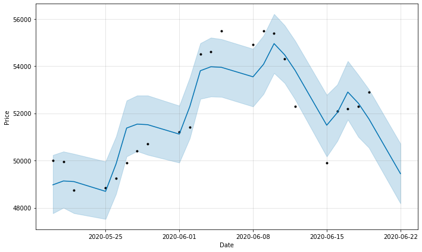

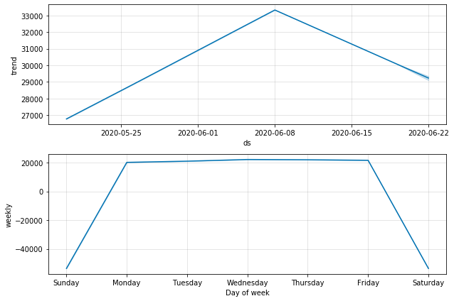

### 에스오일

에스오일의 주가를 Prophet을 통해 간단히 예측해 보겠습니다.  
먼저 종목 코드를 얻기 위한 회사 이름을 찾아봅니다.

```
'010950.KS'
```

사용할 데이터의 시작 날짜와 종료 날짜를 선택합니다.  
예측은 종료 날짜 이후부터의 기간을 말합니다.

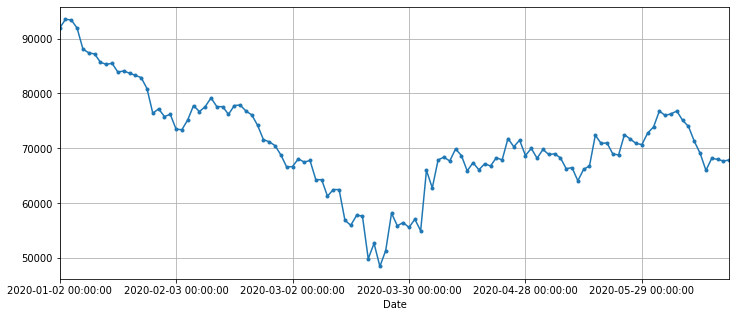

주어진 데이터에서 3일 뒤의 자료까지 예측한다고 해봅시다.  
즉, 2020-06-19 이후로 2020-06-22 까지 3일 간의 자료를 예측해 봅니다.

```
INFO:fbprophet:Disabling yearly seasonality. Run prophet with yearly_seasonality=True to override this.
INFO:fbprophet:Disabling daily seasonality. Run prophet with daily_seasonality=True to override this.
```

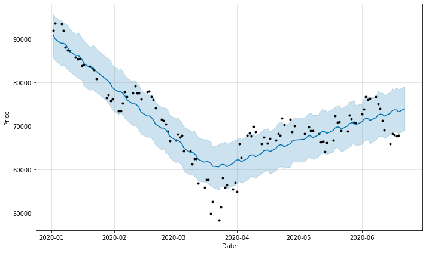

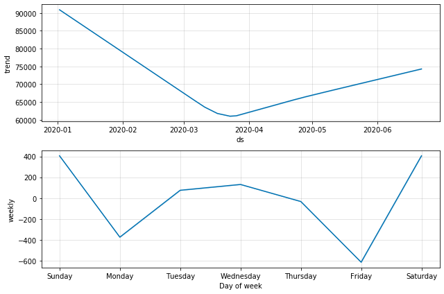

더 많은 데이터를 가져오면 어떤 점이 달라질까요?  
2015년도부터의 데이터를 사용해 보겠습니다.

```
INFO:fbprophet:Disabling daily seasonality. Run prophet with daily_seasonality=True to override this.
```

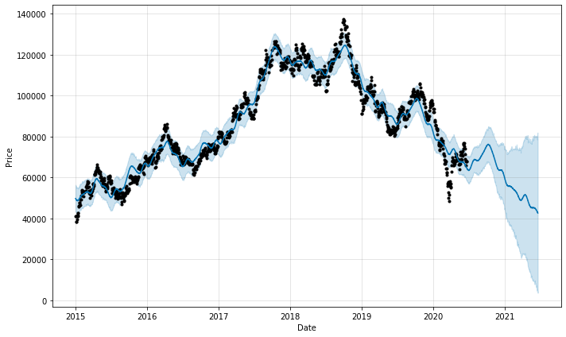

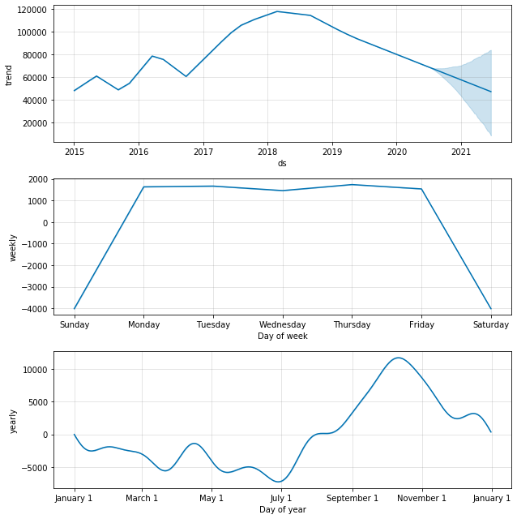

2011년도부터의 데이터를 사용해 보겠습니다.

```
INFO:fbprophet:Disabling daily seasonality. Run prophet with daily_seasonality=True to override this.
```

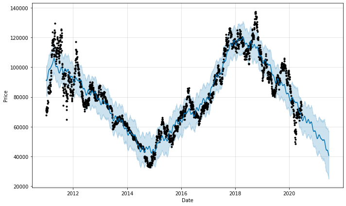

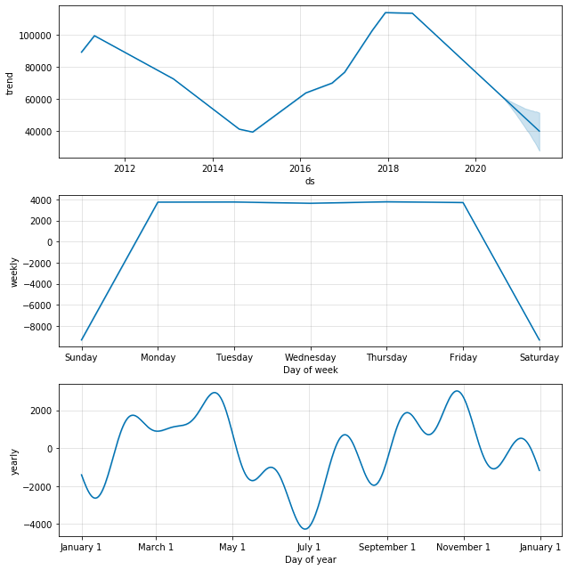

# 참고자료

- Facebook Prophet https://facebook.github.io/prophet/
- Using Facebook’s Prophet to Predict Mongolian Stocks https://medium.com/mongolian-data-stories/using-facebooks-prophet-to-predict-mongolian-stocks-cdf4feabd558